# Divvy Rental Bikes

Francisca Ljubetic

14-12-2023

# **Case: Divvy Chicago Rental Bykes** 🚲

**Final Project, Google Data Analytics Certificate** Francisca Ljubetic, December 2023

This paper has been created from authorized and free data. If required, follow these links: - [Dataset](https://divvy-tripdata.s3.amazonaws.com/index.html) - [License](https://divvybikes.com/data-license-agreement)

## **Business Task**

This documents aims to highlight relevant points for Divvy’s Cyclistic Rental Bikes future marketing program.

Three questions guide the future marketing program: 1. How do members (member) and casual riders (casual) differ with respect to their use of Cyclistic bicycles? 2. Why would casual cyclists purchase Cyclistic annual memberships? 3. How can Cyclistic use digital media to influence casual riders to become members?

This paper attempts to answer the difference between member and casual users

### Data preparation:

Firstly, I tried to process data with BigQuery, because of its weight (some files weight more than 70MB). But sadly free tier was not able to aggregate required new columns.

Then, I tried to bring everything here, to POSIT. But again, sheets were to heavy.

Finally, I could process sheets first by googlesheets, and then at my local Rstudio and it worked fine!!

Once with light pivot sheets in hand, I could use POSIT to make figures and to publish this work. [Whole process- GitHub](https://github.com/FranciscaLjubetic/divvy_bikes/tree/main)

**GoogleSheets**

```
a.-upload every sheet to googlesheets
b.-check and clean empty values and compare colnames
c.-aggregate columns 'WEEKDAY'(formula) and 'ride_length'(D2-E2)
d.-add format 'duration'to 'ride_lenght' and 'datetime' to 'start_time'and 'end_time'
e.-add format '00.000' to 'start_lat', 'start_lng', 'end_lat', 'end_lng'
f.-fill empty values related to 'end_lat' and 'end_lng' with a formula according to average distance of previous sheets (I didn't want to loose data and I realized this missing point were only a 0.01% of total, discardable in terms of distances and time, but maybe not regard bike types)
g.-download as csv
```

**Rstudio**

[output not shown]

## **Analysis**

### Summary:

*A First approximation* After clean data, there were recognized: - 2 User types: member, casual - 3 types of rental bike: classic, electric and docked - 12 months between November, 2022 and October 2023

*the first natural questions were:* - How many trips are made by members and casual users during the months of the year under study? - What was the mode between weekdays? - What was the average distance and rental-time per trip each user type made during those 12 months?

*How many trips take members and casual users in a year? How many daily? Does every month or every day per month register trips?***_

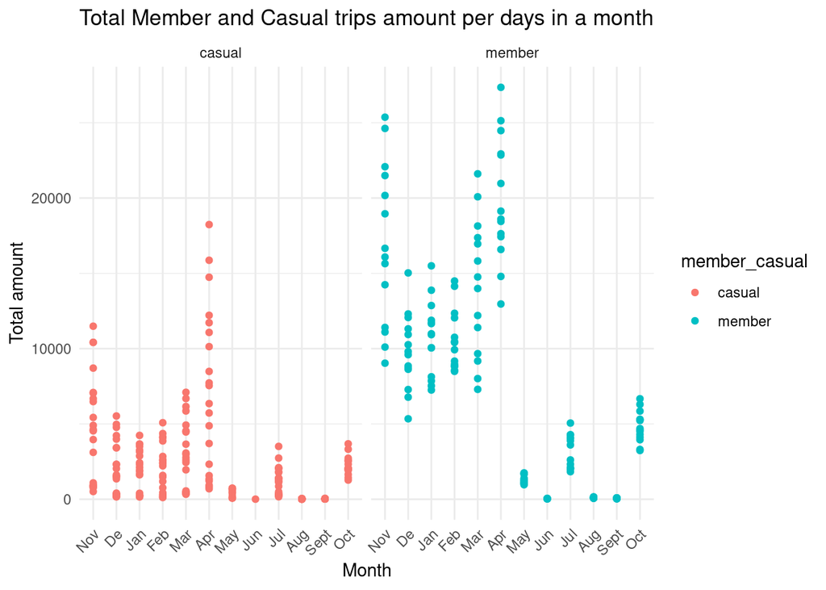

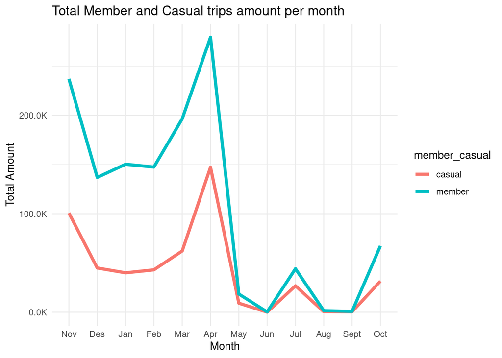

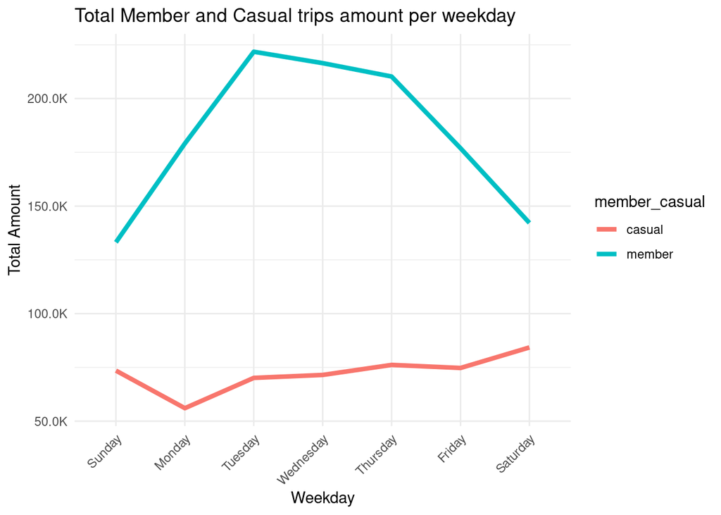

Before continue, I decided to make the same exercise to compare totals, but now regard bike types in order to know how much each type was used the last year.

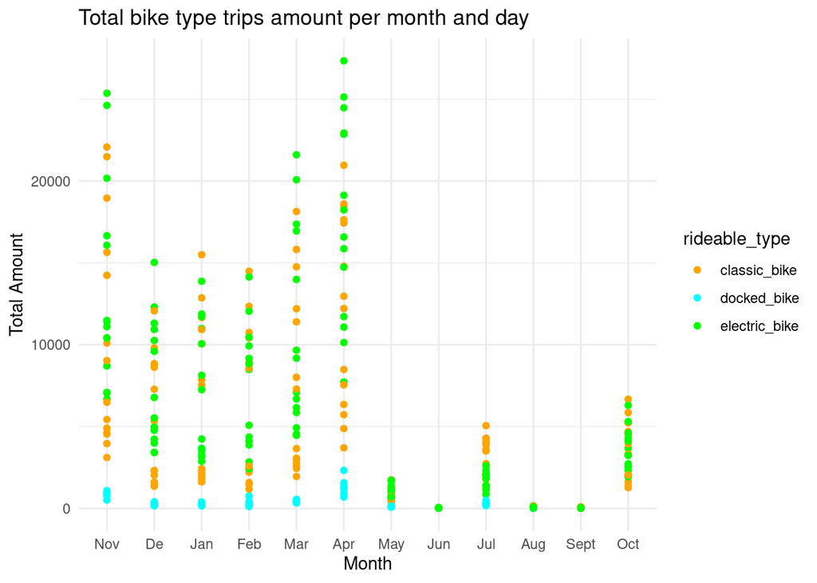

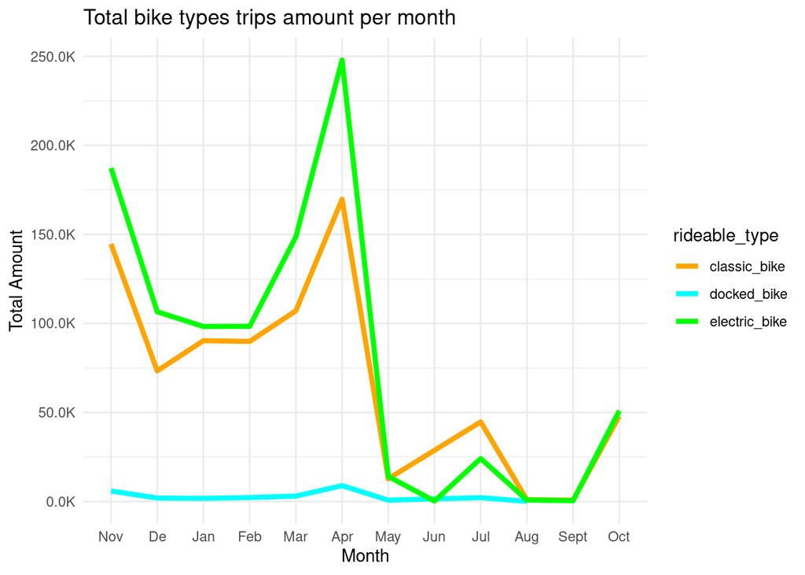

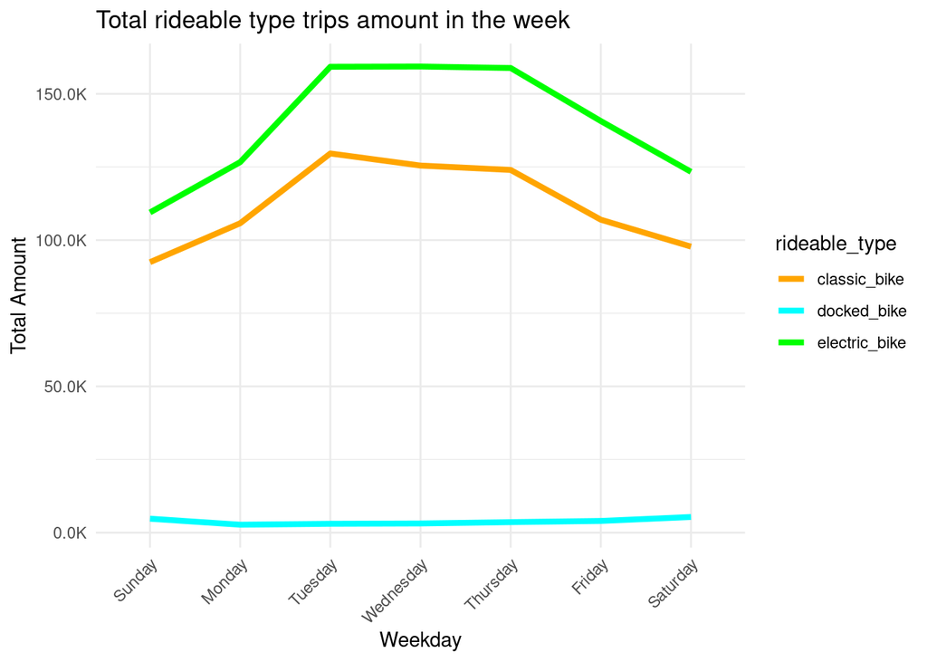

A took a last step to watch how long are the trips depending on user type. Surprisingly, in low season averages are prone to increase, and this curve repeats no matter the user type. Then I sum total distances traveled by each user type and I found the curve coheres with trips number curves.

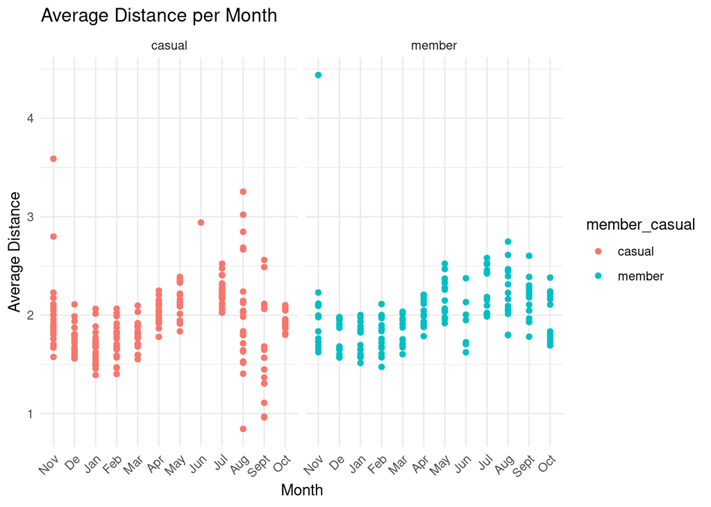

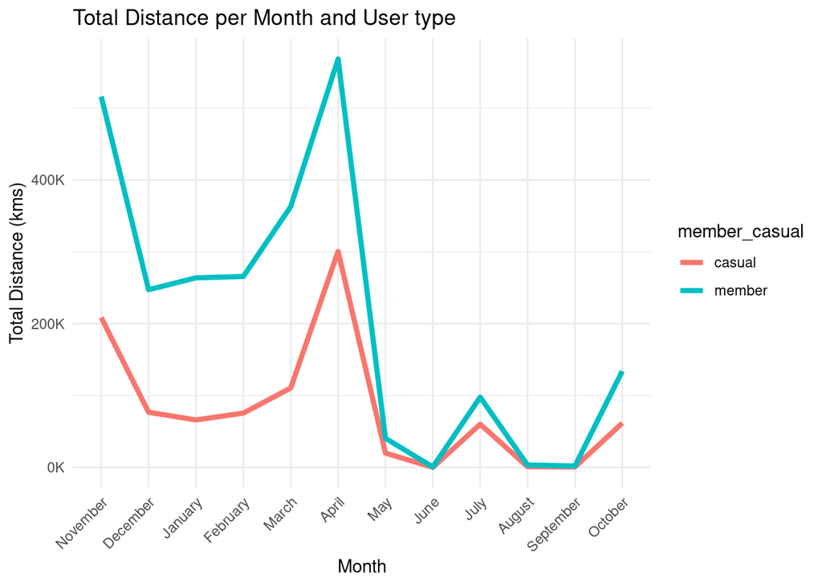

It was not part of this exercise to know the commercial criteria. I explored distances and number of trips, but now was the turn for the time: renting time. Surprisingly the bikes rental time at April´s peak is the same between casual members and users. No matter how many kilometers casual members traveled, they kept the bikes for a total mount of time equal to members. This fact was confirmed by the next figure which shows casual users “touch” members by the weekends.

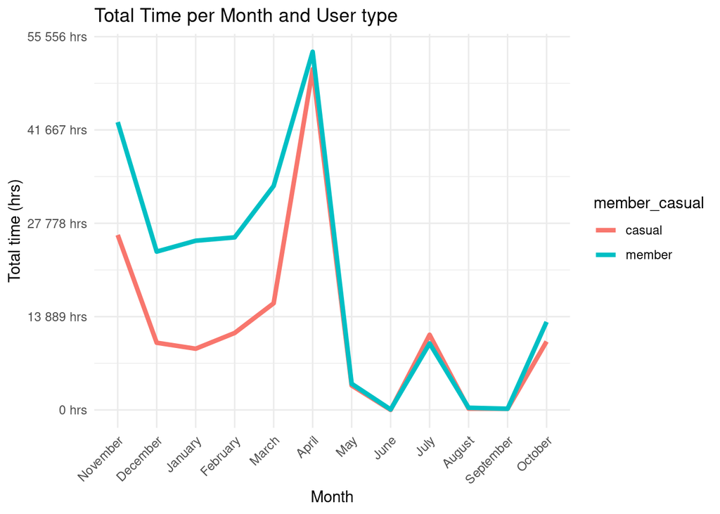

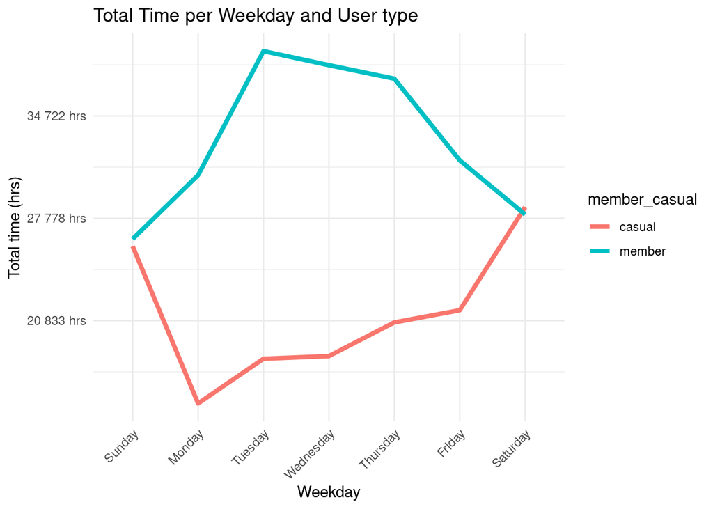

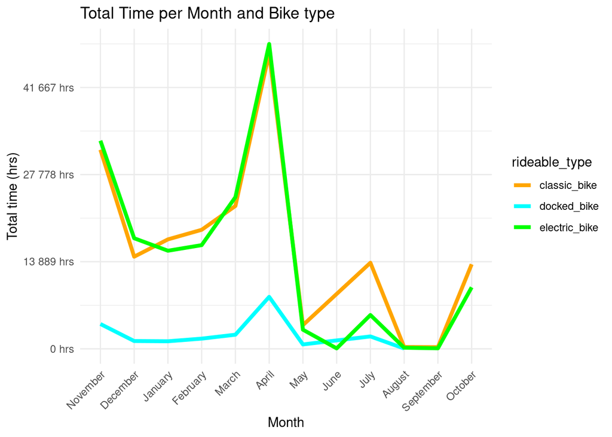

Finally I opted to watch a comparative landscape of Bike rental times per user and per bike type.

[figure not shown]

### Conclusions

Members and Casual users uses in a similar ratio bikes per season.

Rental time in weekends is the same for casual users and members. But members use more bikes during the workable week, while casual users use a little bit more in weekends

Members almost do not use docked bikes, and the ratio per user type between electrical bike and classical bike is almost the same.

Casual users take longer (in time) but fewer trips.

Suggested gaps to solve are: - Increase members trips in weekends - Increase casual users to ride bikes in workable days, or transform them in members.